# Functions Lab - Key

# Part 1

Load all the libraries we will use in this lab.

```r
library(tidyverse)
```

### 1.1

Create a function that takes one argument, a vector, and returns the sum of the vector and squares the result. Call it “sum_squared”. Test your function on the vector `c(2,7,21,30,90)` - you should get the answer 22500.

```
# General format
NEW_FUNCTION <- function(x, y) x + y
```

or

```
# General format
NEW_FUNCTION <- function(x, y){
result <- x + y
return(result)
}
```

```r
nums <- c(2, 7, 21, 30, 90)

sum_squared <- function(x) sum(x)^2
sum_squared(x = nums)
```

```
## [1] 22500
```

```r
sum_squared <- function(x) {
  out <- sum(x)^2
  return(out)
}
sum_squared(x = nums)
```

```
## [1] 22500
```

### 1.2

Create a function that takes two arguments, (1) a vector and (2) a numeric value. This function tests whether the number (2) is contained within the vector (1). **Hint**: use `%in%`. Call it `has_n`. Test your function on the vector `c(2,7,21,30,90)` and number `21` - you should get the answer TRUE.

```r
nums <- c(2, 7, 21, 30, 90)
a_num <- 21

has_n <- function(x, n) n %in% x
has_n(x = nums, n = a_num)
```

```
## [1] TRUE
```

### 1.3

Amend the function `has_n` from question 1.2 so that it takes a default value of `21` for the numeric argument.

```r
nums <- c(2, 7, 21, 30, 90)
a_num <- 21

has_n <- function(x, n = 21) n %in% x
has_n(x = nums)
```

```
## [1] TRUE
```

### 1.4

Create a new number `b_num` that is not contained within the vector `nums`. Use your updated `has_n` function from 1.3 with the default value and add `b_num` as the value for the `n` argument when calling the function. What is the outcome?

```r
b_num <- 11
has_n(x = nums, n = b_num)
```

```
## [1] FALSE
```

# Practice on Your Own!

### P.1

Take your function from question 1.1 and have it make a print statement describing what the function is doing.

```r
sum_squared_explain <- function(x) {
  out <- sum(x)^2
  print("Take the sum of x, then square it.")
  return(out)
}
sum_squared_explain(x = c(1, 2, 3, 4, 5))
```

```
## [1] "Take the sum of x, then square it."
```

```
## [1] 225
```

# Part 2

### 2.1

Read in the SARS-CoV-2 Vaccination data from http://jhudatascience.org/intro_to_r/data/USA_covid19_vaccinations.csv. Assign the data the name “vacc”.

```r
vacc <- read_csv("http://jhudatascience.org/intro_to_r/data/USA_covid19_vaccinations.csv")
# If downloaded
# vacc <- read_csv("USA_covid19_vaccinations.csv")
```

### 2.2

We want to get some summary statistics on the Moderna vaccines. Use `across` inside `summarize` to get the sum total number vaccine doses for any variable containing the word “Moderna” AND starting with “Total”. **Hint**: use `contains()` AND `starts_with()` to select the right columns inside `across`. Keep in mind that this includes the United States as a whole and so it is not totally accurate! Remember that `NA` values can influence calculations.

```
# General format
data %>%
  summarize(across(
    .cols = {vector or tidyselect},
    .fns = {some function})
  ))
```

OR

```
# General format
data %>%
  summarize(across(
    .cols = {vector or tidyselect},
    .fns = function(x) {some function}(x, {additional arguments})
  ))
```

```r
vacc %>%
  summarize(across(
    .cols = contains("Moderna") & starts_with("Total"),
    .fns = sum
  ))
```

```
## # A tibble: 1 × 4
##   Total Number of Moderna doses …¹ Total Number of Mode…² Total Count People w…³
##                              <dbl>                  <dbl>                  <dbl>
## 1                        482227080              403816391                     NA
## # ℹ abbreviated names: ¹`Total Number of Moderna doses delivered`,
## #   ²`Total Number of Moderna doses administered`,
## #   ³`Total Count People w/Booster Primary Moderna Minus TX`
## # ℹ 1 more variable:
## #   `Total Count People w/Booster Booster Moderna Minus TX` <dbl>
```

```r
vacc %>%
  summarize(across(
    .cols = contains("Moderna") & starts_with("Total"),
    .fns = function(x) sum(x, na.rm = TRUE)
  ))
```

```
## # A tibble: 1 × 4
##   Total Number of Moderna doses …¹ Total Number of Mode…² Total Count People w…³
##                              <dbl>                  <dbl>                  <dbl>
## 1                        482227080              403816391               29736587
## # ℹ abbreviated names: ¹`Total Number of Moderna doses delivered`,
## #   ²`Total Number of Moderna doses administered`,
## #   ³`Total Count People w/Booster Primary Moderna Minus TX`
## # ℹ 1 more variable:
## #   `Total Count People w/Booster Booster Moderna Minus TX` <dbl>
```

### 2.3

Use `across` and `mutate` to convert all columns containing the word “Percent” into proportions (i.e., divide that value by 100). **Hint**: use `contains()` to select the right columns within `across()`. Use a “function on the fly” to divide by 100. It will also be easier to check your work if you `select()` columns that match “Percent”.

```r
vacc %>%
  mutate(across(
    .cols = contains("Percent"),
    .fns = function(x) x / 100
  )) %>%
  select(contains("Percent"))
```

```
## # A tibble: 64 × 34
##    Percent of Total Pop with at …¹ Percent of 18+ Pop w…² Percent of Total Pop…³
##                              <dbl>                  <dbl>                  <dbl>
##  1                           0.746                  0.866                  0.627
##  2                           0.657                  0.776                  0.568
##  3                           0.593                  0.711                  0.482
##  4                           0.636                  0.751                  0.518
##  5                           0.876                  0.95                   0.76
##  6                           0.684                  0.792                  0.577
##  7                          NA                     NA                     NA
##  8                           0.843                  0.95                   0.67
##  9                           0.754                  0.869                  0.668
## 10                           0.905                  0.95                   0.755
## # ℹ 54 more rows
## # ℹ abbreviated names:
## #   ¹`Percent of Total Pop with at least One Dose by State of Residence`,
## #   ²`Percent of 18+ Pop with at least One Dose by State of Residence`,
## #   ³`Percent of Total Pop Fully Vaccinated by State of Residence`
## # ℹ 31 more variables:
## #   `Percent of 18+ Pop Fully Vaccinated by State of Residence` <dbl>, …
```

### 2.4

Use `across` and `mutate` to convert all columns starting with the word “Total” into a binary variable: TRUE if the value is greater than 10,000,000 and FALSE if less than or equal to 10,000,000. **Hint**: use `starts_with()` to select the columns starting with “Total”. Use a “function on the fly” to do a logical test if the value is greater than 10,000,000.

```r
vacc %>%
  mutate(across(
    .cols = starts_with("Total"),
    .fns = function(x) x > 10000000
  ))
```

```
## # A tibble: 64 × 125
##    State/Territory/Federal Entit…¹ Total Doses Delivere…² Doses Delivered per …³
##    <chr>                           <lgl>                                   <dbl>
##  1 United States                   TRUE                                   194167
##  2 Alaska                          FALSE                                  185553
##  3 Alabama                         FALSE                                  175845
##  4 Arkansas                        FALSE                                  177298
##  5 American Samoa                  FALSE                                  179165
##  6 Arizona                         TRUE                                   180044
##  7 Bureau of Prisons               FALSE                                      NA
##  8 California                      TRUE                                   201694
##  9 Colorado                        TRUE                                   194586
## 10 Connecticut                     FALSE                                  218700
## # ℹ 54 more rows
## # ℹ abbreviated names: ¹`State/Territory/Federal Entity`,
## #   ²`Total Doses Delivered`, ³`Doses Delivered per 100K`
## # ℹ 122 more variables: `18+ Doses Delivered per 100K` <dbl>,
## #   `Total Doses Administered by State where Administered` <lgl>,
## #   `Doses Administered per 100k by State where Administered` <dbl>,
## #   `18+ Doses Administered by State where Administered` <dbl>, …
```

# Practice on Your Own!

### P.2

Take your code from question 2.4 and assign it to the dataset `vacc_dat`.

- use `filter()` to drop any rows where “United States” appears in `State/Territory/Federal Entity`. Make sure to reassign this to `vacc_dat`.
- Create a ggplot boxplot (`geom_boxplot()`) where (1) the x-axis is `Total Doses Delivered` and (2) the y-axis is `Percent of fully vaccinated people with booster doses`.
- You change the `labs()` layer so that the x-axis is “Total Doses Delivered: Greater than 10,000,000”

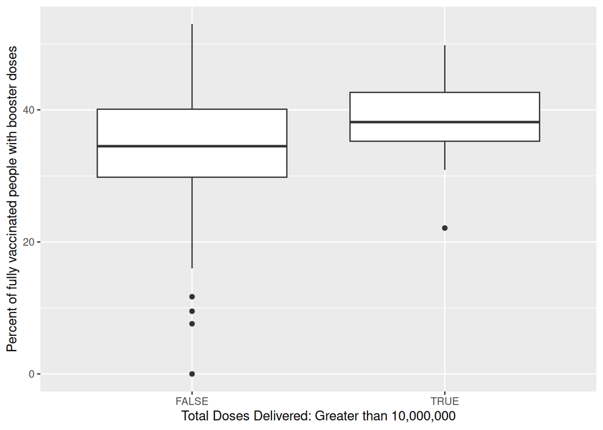

```r
vacc_dat <-
  vacc %>%
  mutate(across(
    .cols = starts_with("Total"),
    .fns = function(x) x > 10000000
  )) %>%
  filter(`State/Territory/Federal Entity` != "United States")

ggplot(vacc_dat) +
  geom_boxplot(aes(
    x = `Total Doses Delivered`,
    y = `Percent of fully vaccinated people with booster doses`
    )) +
  labs(x = "Total Doses Delivered: Greater than 10,000,000")
```